# TidyVerse Vignette

Mustafa Telab

10/25/2020

## 0.1 Introduction

The TidyVerse is a very useful and popular R package that assists in formating, manipulating, and visualizing data. This vignette will focus on the latter.

GGplot2 is a grammatically layerd approch towards visualizations. The combinations of the layers, features, and options are nearly endless, providing a fully customizable visual to cater any data set. For this example, we will be using categorical information based on a Holloween Candy survey.

Below is a very basic snapshot of the GGplot2 package and its potential. Lets tackle the below concepts. -Set-up -Objects -Aesthetics -Facets -Coordinates

```r
#Calling the package
library(tidyverse)
```

```r
#OR
library(ggplot2)
```

```r
library(RCurl)
getfile <- getURL("https://raw.githubusercontent.com/fivethirtyeight/data/master/candy-power-ranking/candy-data.csv")
candy <- read.csv(text = getfile)
```

## 0.2 Getting Started

Assemble the basic point plot, showing candy suger percentage against winning percentage.

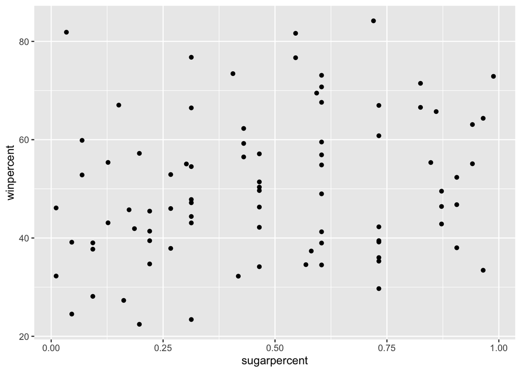

```r
#pass the dataset into the function
candy%>%
  #the "+" introduces the next layer of the visualization
  ggplot() +
  #now we choose the geometric shape, such as a bar graph
  geom_point(aes(x=sugarpercent, y= winpercent))
```

## 0.3 Gemetric Objects

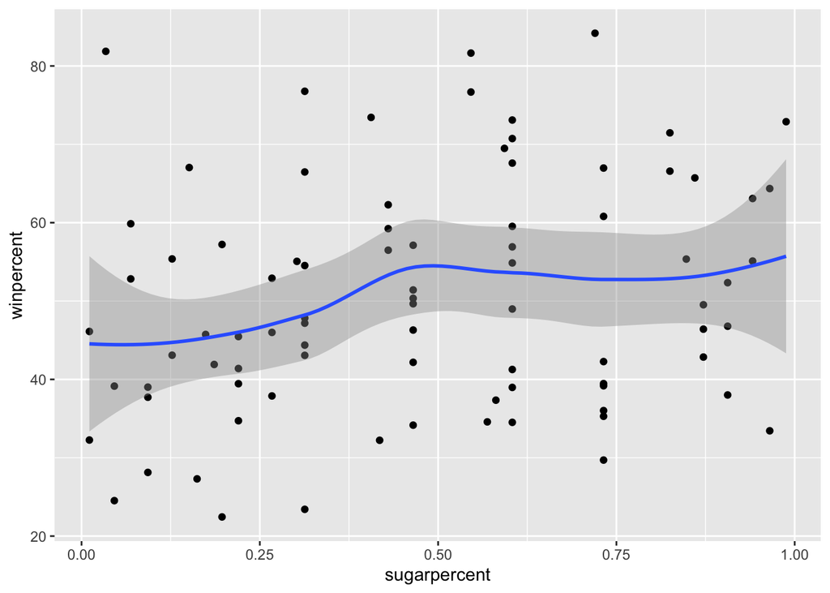

```r
candy%>%
  ggplot() +
  geom_point(aes(x=sugarpercent, y= winpercent))+
  #we can plot the same data more than once as a different shape
  geom_smooth(aes(x=sugarpercent, y= winpercent))
```

## 0.4 Aesthetic

Withing the aesthetic argument, we can alter color and appearance of the plot.

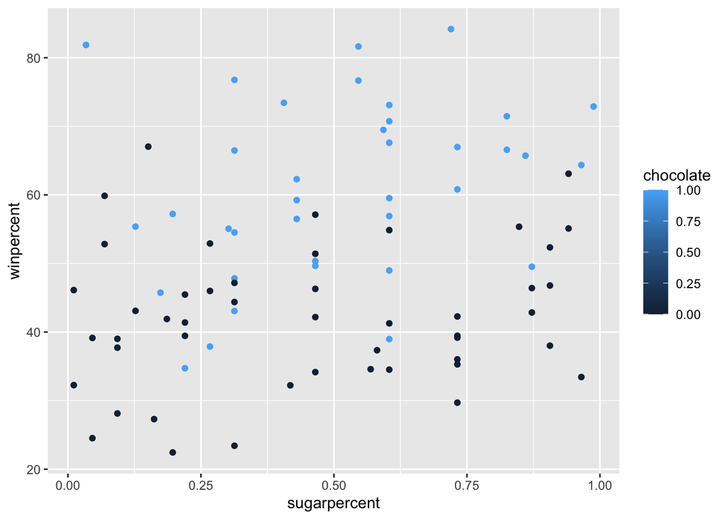

```r
candy%>%
  ggplot() +
  #suppose we want call out wether the point is associated with chocolate or not.
  geom_point(aes(x=sugarpercent, y= winpercent, color = chocolate))
```

```r
  #options other than "color", include size, alpha, and shape
```

## 0.5 Facets

The Facet layer breaks out the plots based on specified parameters

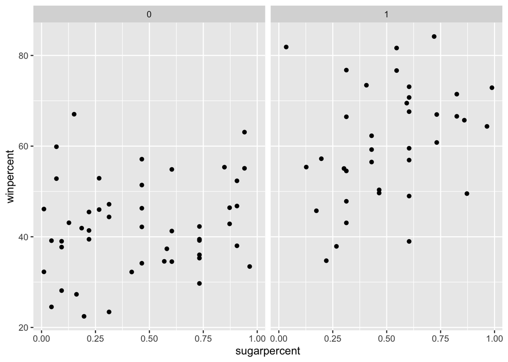

```r
candy%>%
  ggplot() +
  geom_point(aes(x=sugarpercent, y= winpercent)) +
  #We can just add on the additional layer again with the "+"
  facet_grid(~chocolate)
```

## 0.6 Coordinate

Consider the coordinate layer as an option to re-shape the entire plot.

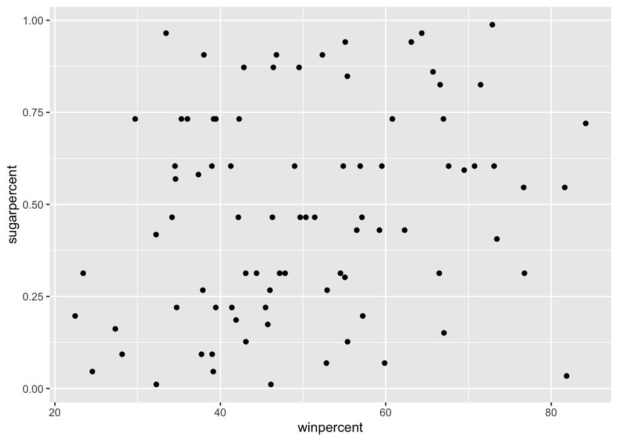

```r
candy%>%
  ggplot() +
  geom_point(aes(x=sugarpercent, y= winpercent)) +
  #one of the more common options is the flip, but you also have "coord_quickmap()", "coord_polar()","coord_fixed()", etc
  coord_flip()
```

## 0.7 Conclusion

Hope you enjoyed the basic introduction to GGplot2, part of the TidyVerse package. The potential spans way beyond what is outlined above. The package allows for scales, labeling, annotations, zooming, and additional themes.

Happy Plotting!